# 市场观察

2017/01/17

## 一、IndexValuation指数估值

### (一)PEPB动态市盈率、市净率

核心指数成分股近18个月的动态市盈率及动态市净率中位数走势如下图所示：

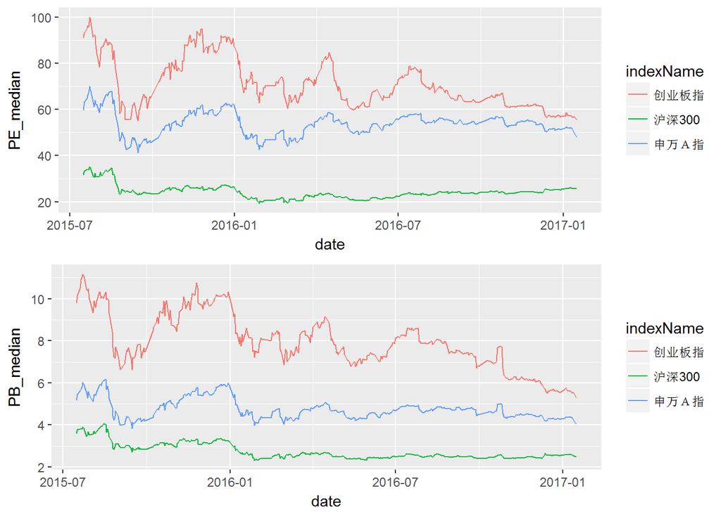

### (二)PEPBPercentile动态市盈率、市净率百分位

核心指数近18个月的动态市盈率百分位及动态市净率百分位走势如下图所示：

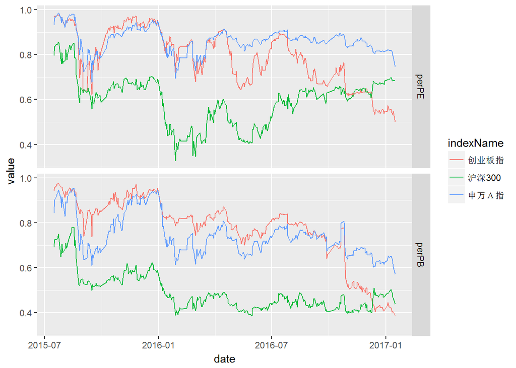

### (三)PEPB指数估值概览

纳入观察的18只指数最新的估值情况如下表：

| 日期 | 指数代码 | 指数简称 | 动态市盈率 | 市盈率百分位 | 动态市净率 | 市净率百分位 |
| --- | --- | --- | --- | --- | --- | --- |
| 2017-01-16 | EI000805 | A股资源 | 79.9 | 98.0% | 2.6 | 62.6% |
| 2017-01-16 | EI000979 | 大宗商品 | 53.1 | 94.9% | 2.9 | 67.1% |
| 2017-01-16 | EI000819 | 有色金属 | 56.7 | 77.8% | 3.3 | 44.7% |
| 2017-01-16 | EI801003 | 申万Ａ指 | 47.9 | 74.6% | 4.0 | 57.1% |
| 2017-01-16 | EI000300 | 沪深300 | 25.6 | 68.4% | 2.5 | 43.8% |
| 2017-01-16 | EI000808 | 医药生物 | 41.7 | 68.4% | 4.4 | 16.2% |
| 2017-01-16 | EI399330 | 深证100 | 32.6 | 67.3% | 3.8 | 55.5% |
| 2017-01-16 | EI000827 | 中证环保 | 41.7 | 66.1% | 3.0 | 23.2% |
| 2017-01-16 | EI399005 | 中小板指P | 40.3 | 62.0% | 4.5 | 39.2% |
| 2017-01-16 | EI000016 | 上证50 | 17.7 | 60.5% | 1.6 | 14.4% |
| 2017-01-16 | EI000933 | 中证医药 | 38.4 | 58.4% | 3.8 | 2.7% |
| 2017-01-16 | EI399959 | 军工指数 | 81.4 | 57.8% | 5.2 | 64.1% |
| 2017-01-16 | EI000934 | 中证金融 | 18.3 | 56.5% | 1.9 | 28.5% |
| 2017-01-16 | EI000905 | 中证500 | 37.9 | 54.9% | 3.0 | 35.9% |
| 2017-01-16 | EI399006 | 创业板指 | 55.3 | 50.1% | 5.3 | 38.6% |
| 2017-01-16 | EI801120 | 申万食品饮料 | 37.0 | 41.5% | 4.2 | 46.8% |
| 2017-01-16 | EI000998 | 中证TMT | 41.3 | 39.2% | 4.0 | 34.0% |
| 2017-01-16 | EI000932 | 中证消费 | 28.2 | 17.0% | 3.5 | 6.8% |

## 二、Spread基差

### (一)Spread基差走势

三大股指期货合约基差走势如下图，其中当月合约和次月合约年化基差百分比波动较大，仅展示合约基差百分比，当季合约和次季合约展示基差年化百分比：

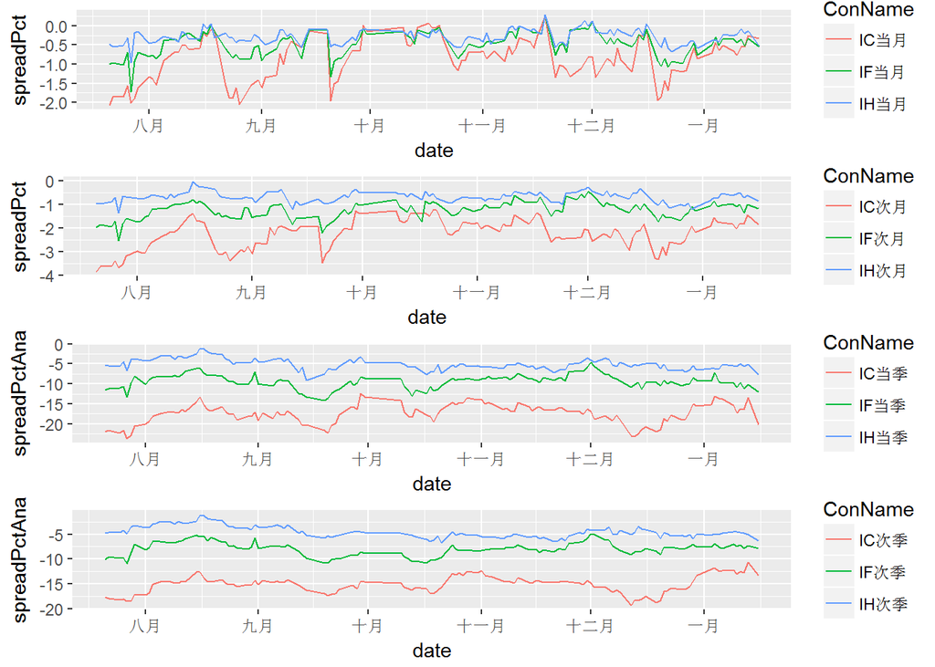

### (二)Spread基差概况

三大股指期货连续合约基差概况如下表，近月合约临近到期日，年化基差百分比数据波动较大：

| 日期 | 合约代码 | 合约收盘价 | 指数收盘价 | 基差 | 基差百分比 | 年化基差百分比 |
| --- | --- | --- | --- | --- | --- | --- |
| 2017-01-16 | IC1701 | 6011.4 | 6031.24 | -19.84 | -0.33% | -34.9% |
| 2017-01-16 | IC1702 | 5920.4 | 6031.24 | -110.84 | -1.84% | -23.1% |
| 2017-01-16 | IC1703 | 5846.0 | 6031.24 | -185.24 | -3.07% | -20.2% |
| 2017-01-16 | IC1706 | 5711.2 | 6031.24 | -320.04 | -5.31% | -13.3% |
| 2017-01-16 | IF1701 | 3301.2 | 3319.45 | -18.25 | -0.55% | -64.9% |
| 2017-01-16 | IF1702 | 3281.0 | 3319.45 | -38.45 | -1.16% | -14.0% |
| 2017-01-16 | IF1703 | 3256.4 | 3319.45 | -63.05 | -1.90% | -12.1% |
| 2017-01-16 | IF1706 | 3213.0 | 3319.45 | -106.45 | -3.21% | -7.9% |
| 2017-01-16 | IH1701 | 2325.2 | 2337.39 | -12.19 | -0.52% | -60.8% |
| 2017-01-16 | IH1702 | 2317.8 | 2337.39 | -19.59 | -0.84% | -10.0% |
| 2017-01-16 | IH1703 | 2308.4 | 2337.39 | -28.99 | -1.24% | -7.8% |
| 2017-01-16 | IH1706 | 2278.0 | 2337.39 | -59.39 | -2.54% | -6.3% |

## 三、Arbitrage套利

### (一)Arbitrage复牌股票套利

近两天复牌股票套利情况如下表：

[1] “无复牌股票套利”

### (二)Arbitrage定增基金跟踪

截止2017-01-17定增基金数据如下表，明细数据参见钱瀚的模板。

| 代码 | 名称 | 到期日期 | 最新净值 | 昨日收盘价 | 折溢价率 | 整体隐含折价率 | 大盘回撤0.1净值回撤 |
| --- | --- | --- | --- | --- | --- | --- | --- |
| 168101.OF | 九泰锐智 | 20200814 | 1.14 | 1.07 | -6.6% | 4.2% | -8.7% |
| 168102.OF | 九泰锐富 | 20210204 | 1.01 | 0.92 | -9.0% | 2.8% | -4.7% |
| 501015.OF | 财通升级 | 20170908 | 1.00 | 0.98 | -1.7% | 4.6% | -7.8% |
| 160518.OF | 博时睿远 | 20171016 | 0.96 | 0.95 | -0.8% | 2.1% | -5.6% |

定增基金近期的净值走势如下图：

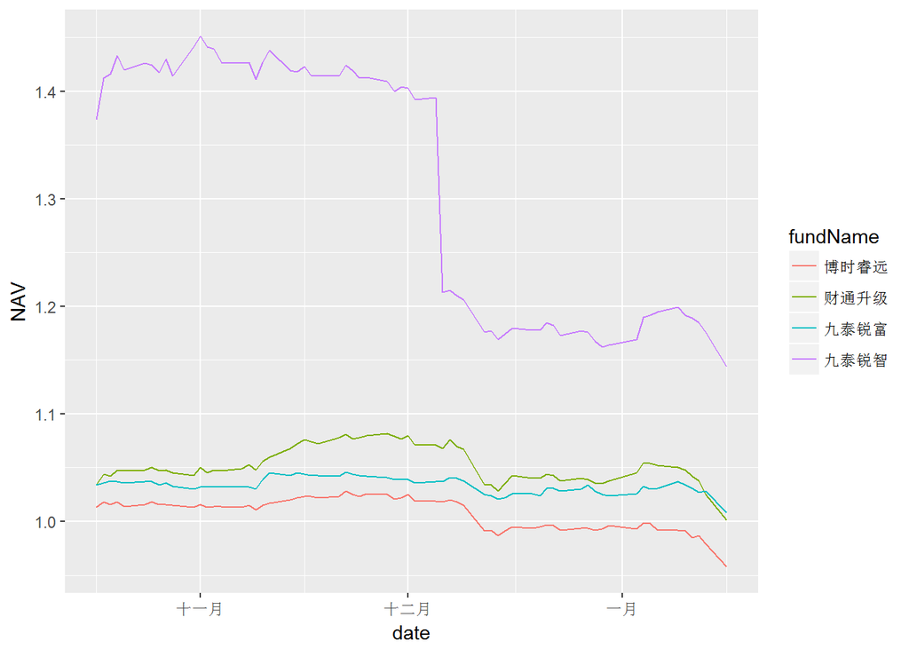

定增基金近期的折溢价率百分比走势如下图：

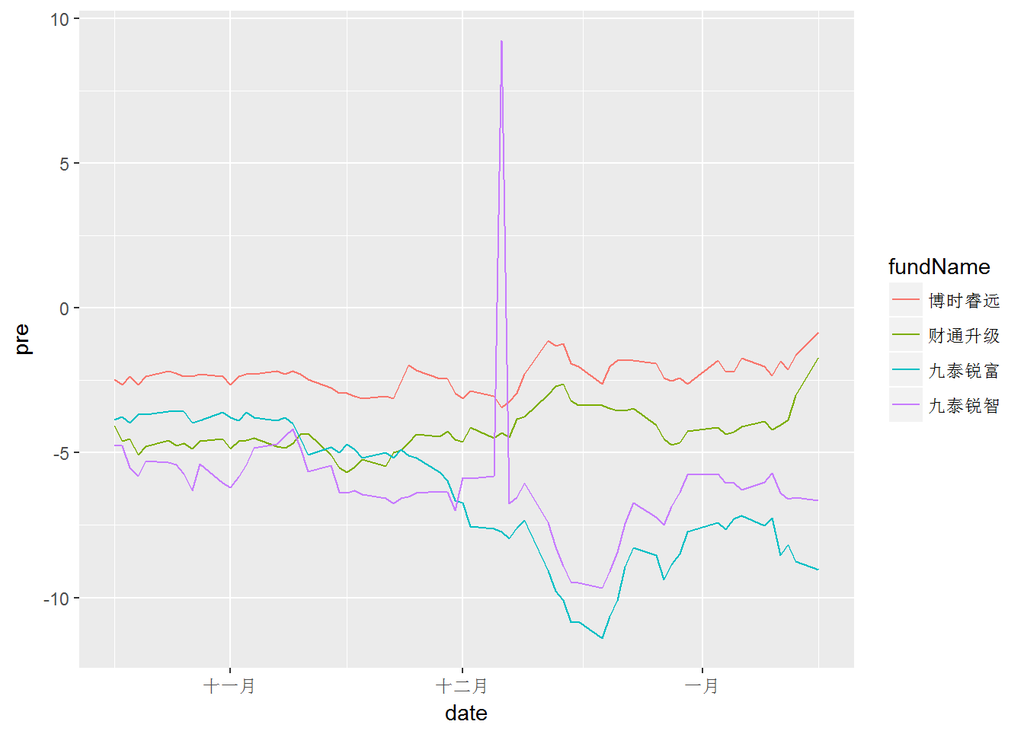

## 四、Timing择时

### (一)EqualWeightIndex等权指数

从历史来看，A股市场存在小盘股效应，市值小的股票长期整体跑赢大市值的股票，美股市场同样存在类似的现象。而目前大部分指数的编制方案都是类似市值加权，为了抛去市值的影响，下面展示几个等权指数，其中中证500等权和沪深300等权是现有的指数，中证全指等权是自己编制的指数。等权指数可以视为一个更好地业绩比较基准。等权指数走势如下图：

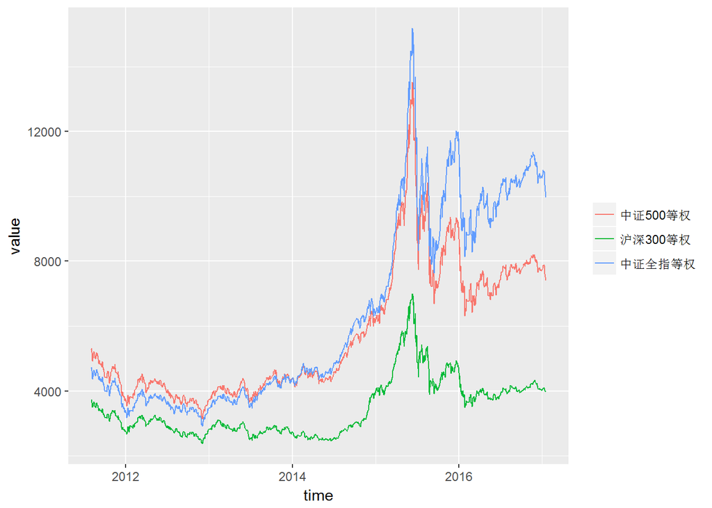

等权指数收益率统计见下表：

|  | 中证500等权 | 沪深300等权 | 中证全指等权 |
| --- | --- | --- | --- |
| 2011-08-02 ~ 2011-12-30 | -29.2% | -25.5% | -28% |
| 2012-01-04 ~ 2012-12-31 | 0.0% | 1.5% | 2% |
| 2013-01-04 ~ 2013-12-31 | 16.7% | -3.2% | 26% |
| 2014-01-02 ~ 2014-12-31 | 40.2% | 43.7% | 46% |
| 2015-01-05 ~ 2015-12-31 | 47.6% | 20.1% | 84% |
| 2016-01-04 ~ 2016-12-30 | -15.1% | -15.1% | -10% |
| 2017-01-03 ~ 2017-01-16 | -4.0% | -1.2% | -6% |
| 累计收益率 | 39.3% | 6.2% | 111% |
| 年化收益率 | 6.3% | 1.1% | 15% |
| 年化波动率 | 29.2% | 26.5% | 30% |
| 年化Sharpe值 | 21.4% | 4.2% | 50% |
| 最大回撤 | 53.3% | 50.0% | 50% |

### (二)Timing大盘均线强弱指数

大盘均线强弱指数在一定程度上可以视为一个反转指标，当大盘均线得分接近8分时，预示市场接近顶部，当大盘均线得分接近0分时，预示市场接近底部。  
大盘均线强弱指数近一年来走势如下图：

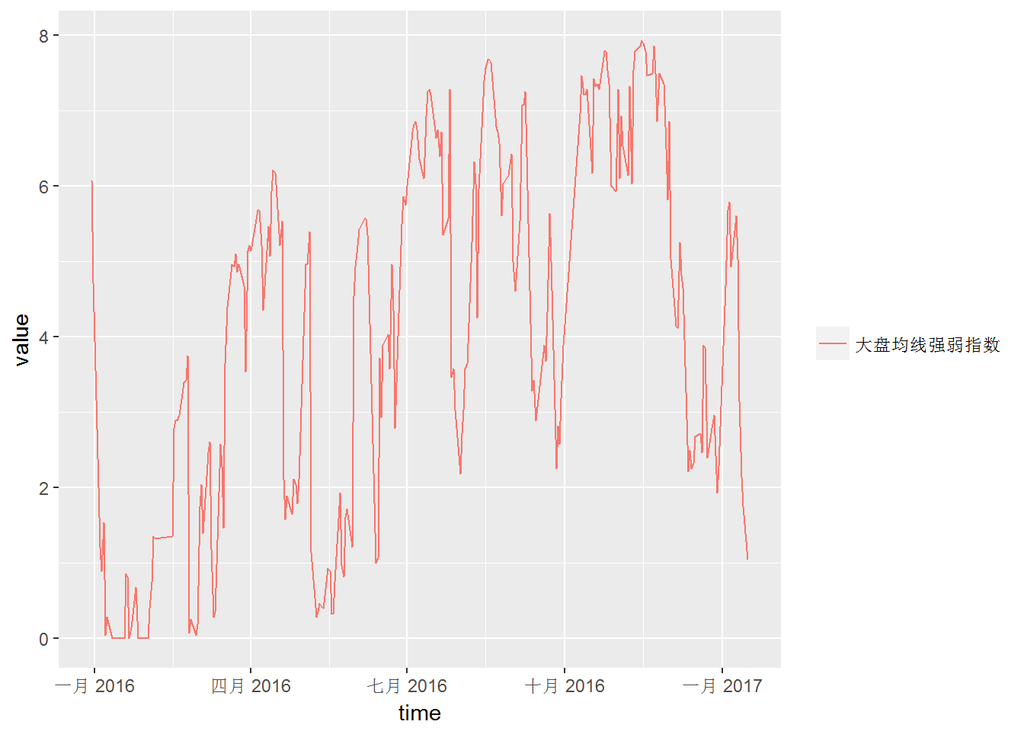

申万一级行业的最新得分见下表：

| 日期 | 指数代码 | 行业 | 最新得分 | 上周得分 |
| --- | --- | --- | --- | --- |
| 2017-01-16 | EI801780 | 银行 | 8 | 4 |
| 2017-01-16 | EI801040 | 钢铁 | 5 | 8 |
| 2017-01-16 | EI801790 | 非银金融 | 4 | 2 |
| 2017-01-16 | EI801710 | 建筑材料 | 2 | 5 |
| 2017-01-16 | EI801720 | 建筑装饰 | 2 | 6 |
| 2017-01-16 | EI801020 | 采掘 | 1 | 6 |
| 2017-01-16 | EI801030 | 化工 | 1 | 8 |
| 2017-01-16 | EI801110 | 家用电器 | 1 | 6 |
| 2017-01-16 | EI801120 | 食品饮料 | 1 | 8 |
| 2017-01-16 | EI801160 | 公用事业 | 1 | 7 |
| 2017-01-16 | EI801200 | 商业贸易 | 1 | 8 |
| 2017-01-16 | EI801740 | 国防军工 | 1 | 8 |
| 2017-01-16 | EI801880 | 汽车 | 1 | 7 |
| 2017-01-16 | EI801010 | 农林牧渔 | 0 | 4 |
| 2017-01-16 | EI801050 | 有色金属 | 0 | 4 |
| 2017-01-16 | EI801080 | 电子 | 0 | 3 |
| 2017-01-16 | EI801130 | 纺织服装 | 0 | 5 |
| 2017-01-16 | EI801140 | 轻工制造 | 0 | 5 |
| 2017-01-16 | EI801150 | 医药生物 | 0 | 4 |
| 2017-01-16 | EI801170 | 交通运输 | 0 | 8 |
| 2017-01-16 | EI801180 | 房地产 | 0 | 4 |
| 2017-01-16 | EI801210 | 休闲服务 | 0 | 4 |
| 2017-01-16 | EI801230 | 综合 | 0 | 3 |
| 2017-01-16 | EI801730 | 电气设备 | 0 | 4 |
| 2017-01-16 | EI801750 | 计算机 | 0 | 0 |
| 2017-01-16 | EI801760 | 传媒 | 0 | 0 |
| 2017-01-16 | EI801770 | 通信 | 0 | 4 |
| 2017-01-16 | EI801890 | 机械设备 | 0 | 6 |

### (三)LLT及均线择时

LLT本质上是一个改进的单均线择时指标，较原始的均线择时延迟更低。  
择时模型和指数本身的净值走势如下图：

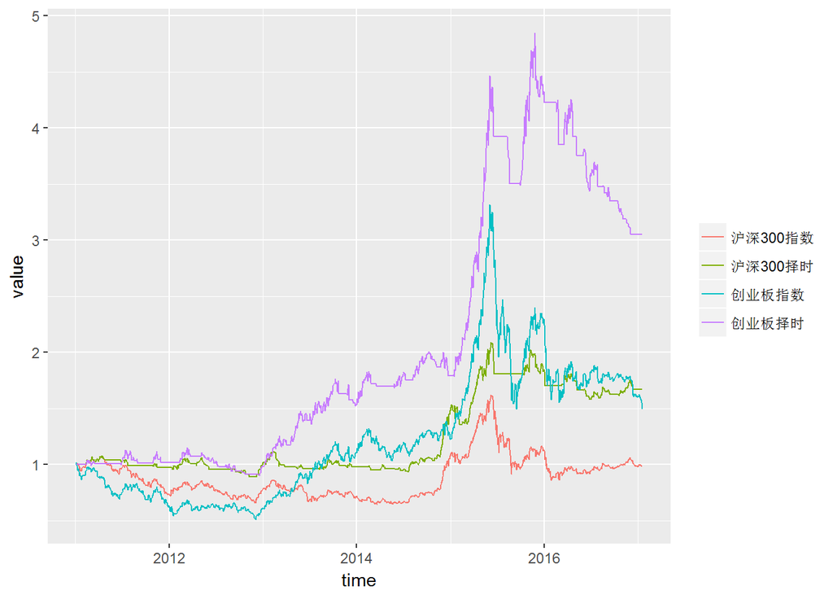

择时模型和指数的收益率统计如下表：

|  | 沪深300指 | 沪深300LLT | 创业板指 | 创业板MA |
| --- | --- | --- | --- | --- |
| 2011-01-04 ~ 2011-12-30 | -25.9% | -2.9% | -37% | 1% |
| 2012-01-04 ~ 2012-12-31 | 6.1% | 4.8% | -3% | -2% |
| 2013-01-04 ~ 2013-12-31 | -8.7% | -3.7% | 81% | 54% |
| 2014-01-02 ~ 2014-12-31 | 49.8% | 51.3% | 11% | 17% |
| 2015-01-05 ~ 2015-12-31 | 4.3% | 23.4% | 82% | 136% |
| 2016-01-04 ~ 2016-12-30 | -12.4% | -8.7% | -29% | -28% |
| 2017-01-03 ~ 2017-01-16 | 0.2% | 0.0% | -7% | 0% |
| 累计收益率 | -1.5% | 67.1% | 49% | 205% |
| 年化收益率 | -0.2% | 8.9% | 7% | 20% |
| 年化波动率 | 24.5% | 15.7% | 33% | 22% |
| 年化Sharpe值 | -1.0% | 56.6% | 21% | 90% |
| 最大回撤 | 47.1% | 24.4% | 55% | 37% |

择时模型最近10个交易日的信号如下表：

| 日期 | 沪深300收盘价 | 沪深300LLT | 沪深300择时信号 | 创业板收盘价 | 创业板MA30 | 创业板择时信号 |
| --- | --- | --- | --- | --- | --- | --- |
| 2017-01-03 | 3342.227 | 3401.476 |  | 1963.255 | 2056.803 |  |
| 2017-01-04 | 3368.312 | 3399.492 |  | 1991.565 | 2050.600 |  |
| 2017-01-05 | 3367.789 | 3398.419 |  | 1983.971 | 2044.542 |  |
| 2017-01-06 | 3347.666 | 3396.711 |  | 1965.030 | 2038.489 |  |
| 2017-01-09 | 3363.901 | 3394.946 |  | 1961.619 | 2031.626 |  |
| 2017-01-10 | 3358.272 | 3393.596 |  | 1951.677 | 2024.480 |  |
| 2017-01-11 | 3334.495 | 3391.343 |  | 1937.547 | 2017.053 |  |
| 2017-01-12 | 3317.624 | 3387.865 |  | 1930.145 | 2008.623 |  |
| 2017-01-13 | 3319.912 | 3384.071 |  | 1899.943 | 1999.224 |  |
| 2017-01-16 | 3319.445 | 3380.510 |  | 1830.848 | 1988.804 |  |

### (四)GridTrade网格交易

在经历了三轮股灾，A股逐步回归正常，在过去的一段时间呈现一个震荡的格局，如果未来没有增量信息，很可能维持震荡。结合股指期货的贴水，前期研究了一下网格交易。网格交易的结果如下图：

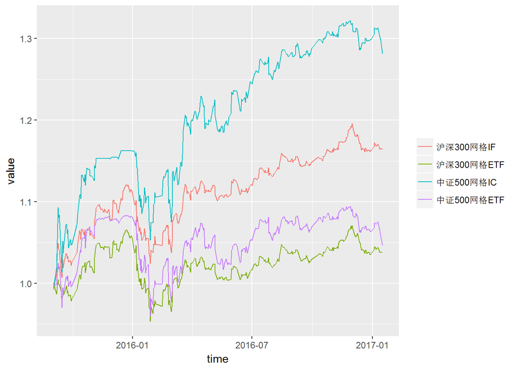

网格交易沪深300股指期货的最新仓位是33.6%，中证500股指期货的最新仓位是36.5%,网格交易的收益统计如下表：

|  | 沪深300指数 | 沪深300网格IF | 沪深300网格ETF | 中证500指数 | 中证500网格IC | 中证500网格ETF |
| --- | --- | --- | --- | --- | --- | --- |
| 2015-09-02 ~ 2015-12-31 | 11.0% | 11% | 5.6% | 23.5% | 16% | 8.1% |
| 2016-01-04 ~ 2016-12-30 | -11.3% | 5% | -1.8% | -17.8% | 12% | -1.6% |
| 2017-01-03 ~ 2017-01-16 | 0.3% | 0% | 0.1% | -3.7% | -1% | -1.6% |
| 累计收益率 | -1.3% | 16% | 3.8% | -2.2% | 28% | 4.7% |
| 年化收益率 | -0.9% | 12% | 2.7% | -1.6% | 20% | 3.4% |
| 年化波动率 | 23.2% | 10% | 9.5% | 31.3% | 14% | 12.2% |
| 年化Sharpe值 | -4.0% | 120% | 29.0% | -5.2% | 137% | 27.6% |
| 最大回撤 | 26.4% | 9% | 10.5% | 33.5% | 9% | 11.4% |

## 五、选股

### (一)SmallStock超级小盘股

作为多因子选股的第一部分，有必要从市值因子说起。 下面利用总市值因子，在中证全指的成分股内，选出市值最小的100只股票，这里剔除了ST、新上市、停牌和涨停的股票，100只股票等权配置，每月换仓一次，交易成本千分之三。超级小盘股策略的净值表现如下图。

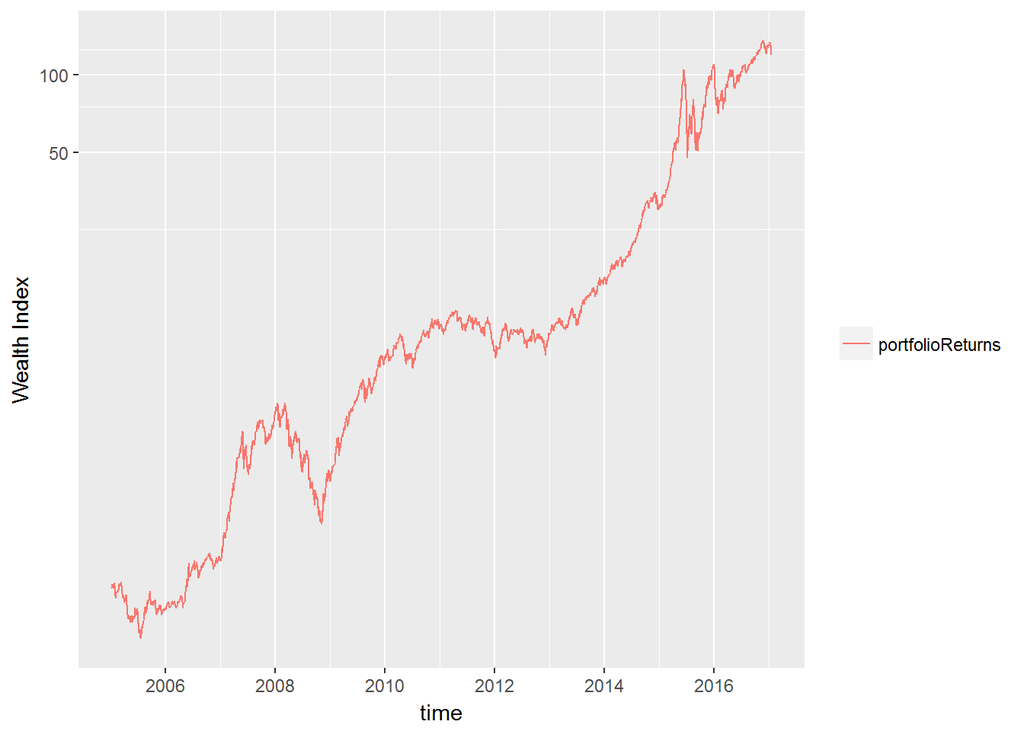

超级小盘股的收益统计如下表：

|  | 超级小盘股 | 沪深300 | 中证500 |
| --- | --- | --- | --- |
| 2005-01-05 ~ 2005-12-30 | -17% | -6% | -13% |
| 2006-01-04 ~ 2006-12-29 | 56% | 121% | 101% |
| 2007-01-04 ~ 2007-12-28 | 265% | 162% | 187% |
| 2008-01-02 ~ 2008-12-31 | -45% | -66% | -61% |
| 2009-01-05 ~ 2009-12-31 | 206% | 97% | 131% |
| 2010-01-04 ~ 2010-12-31 | 32% | -13% | 10% |
| 2011-01-04 ~ 2011-12-30 | -19% | -25% | -34% |
| 2012-01-04 ~ 2012-12-31 | 15% | 8% | 0% |
| 2013-01-04 ~ 2013-12-31 | 63% | -8% | 17% |
| 2014-01-02 ~ 2014-12-31 | 89% | 52% | 39% |
| 2015-01-05 ~ 2015-12-31 | 254% | 6% | 43% |
| 2016-01-04 ~ 2016-12-30 | 21% | -11% | -18% |
| 2017-01-03 ~ 2017-01-16 | -9% | 0% | -4% |
| 累计收益率 | 11848% | 238% | 513% |
| 年化收益率 | 49% | 11% | 16% |
| 年化波动率 | 36% | 29% | 33% |
| 年化Sharpe值 | 136% | 37% | 50% |
| 最大回撤 | 66% | 72% | 72% |

### (二)BankRotation银行股轮动

银行股轮动是参考集思录的热门贴银行股评级而来的，数据的提取和参数的设置和原贴有一定的差别，所以轮动的效果也会不太一样，不过回测的效果还不错，从现在开始跟踪。2013年以来银行股轮动的结果如下图：

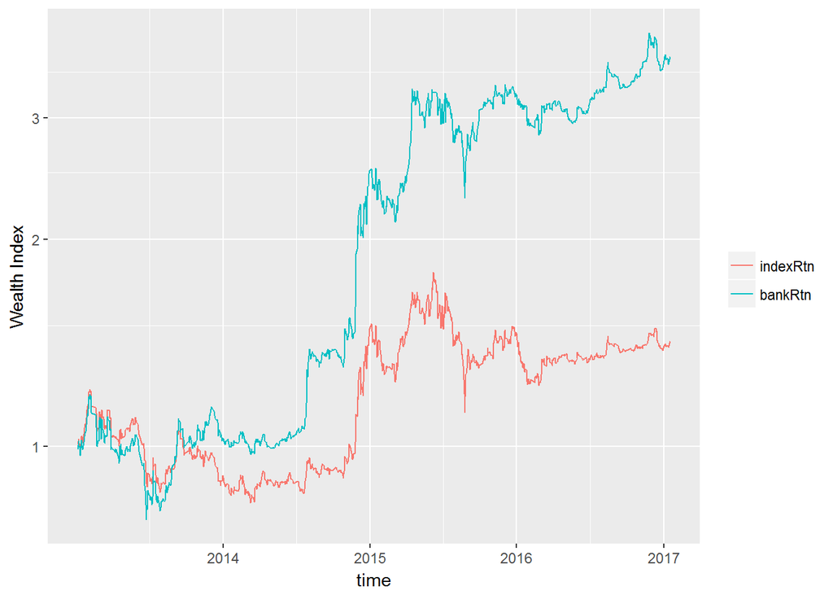

银行股轮动的收益统计如下表：

|  | 申万银行 | 银行股轮动 |
| --- | --- | --- |
| 2013-01-04 ~ 2013-12-31 | -9.2% | 3% |
| 2014-01-02 ~ 2014-12-31 | 63.2% | 145% |
| 2015-01-05 ~ 2015-12-31 | -1.4% | 29% |
| 2016-01-04 ~ 2016-12-30 | -4.9% | 10% |
| 2017-01-03 ~ 2017-01-16 | 2.5% | 3% |
| 累计收益率 | 42.3% | 268% |
| 年化收益率 | 9.1% | 38% |
| 年化波动率 | 28.8% | 33% |
| 年化Sharpe值 | 31.7% | 116% |
| 最大回撤 | 37.4% | 34% |

银行股轮动的最新得分如下表：

| 日期 | 代码 | 简称 | PB | 预期ROE | 翻倍期 | 持仓 |
| --- | --- | --- | --- | --- | --- | --- |
| 2017-01-16 | EQ601818 | 光大银行 | 0.75 | 0.12 | 3.46 |  |
| 2017-01-16 | EQ600015 | 华夏银行 | 0.80 | 0.14 | 3.55 | hold |
| 2017-01-16 | EQ601328 | 交通银行 | 0.71 | 0.10 | 3.57 |  |
| 2017-01-16 | EQ601988 | 中国银行 | 0.74 | 0.11 | 3.70 |  |
| 2017-01-16 | EQ601288 | 农业银行 | 0.78 | 0.12 | 3.88 |  |
| 2017-01-16 | EQ000001 | 平安银行 | 0.79 | 0.12 | 3.97 |  |
| 2017-01-16 | EQ601398 | 工商银行 | 0.83 | 0.13 | 4.25 |  |
| 2017-01-16 | EQ601166 | 兴业银行 | 0.92 | 0.14 | 4.54 |  |
| 2017-01-16 | EQ601939 | 建设银行 | 0.90 | 0.14 | 4.62 |  |
| 2017-01-16 | EQ600000 | 浦发银行 | 0.99 | 0.15 | 5.06 |  |
| 2017-01-16 | EQ601009 | 南京银行 | 1.11 | 0.15 | 5.75 |  |
| 2017-01-16 | EQ600016 | 民生银行 | 1.03 | 0.13 | 6.09 |  |
| 2017-01-16 | EQ601169 | 北京银行 | 1.08 | 0.13 | 6.11 |  |
| 2017-01-16 | EQ600036 | 招商银行 | 1.18 | 0.15 | 6.26 |  |
| 2017-01-16 | EQ601998 | 中信银行 | 0.98 | 0.11 | 6.33 |  |
| 2017-01-16 | EQ002142 | 宁波银行 | 1.33 | 0.16 | 6.67 |  |
| 2017-01-16 | EQ601997 | 贵阳银行 | 1.71 | 0.17 | 7.93 |  |
| 2017-01-16 | EQ600919 | 江苏银行 | 1.36 | 0.13 | 8.12 |  |
| 2017-01-16 | EQ601229 | 上海银行 | 1.30 | 0.12 | 8.40 |  |
| 2017-01-16 | EQ600926 | 杭州银行 | 1.48 | 0.10 | 11.75 |  |
| 2017-01-16 | EQ601128 | 常熟银行 | 2.18 | 0.10 | 14.95 |  |
| 2017-01-16 | EQ600908 | 无锡银行 | 2.07 | 0.10 | 14.98 |  |
| 2017-01-16 | EQ002807 | 江阴银行 | 2.00 | 0.09 | 15.78 |  |
| 2017-01-16 | EQ603323 | 吴江银行 | 2.08 | 0.08 | 18.28 |  |